# Meta-analysis of differential gene expression

Zhe Zhang

2016-06-30

**Introduction**: This analysis is the summary of a set of pairwise comparisons. It performs meta-analysis on the results of differential gene expression generated by [this](https://raw.githubusercontent.com/zhezhangsh/RoCA/master/template/de/pairwise_comparison/pairwise_comparison.Rmd) template. Both gene and gene set-level results of individual comparisons are summarized through visualization and [Fisher’s method](https://en.wikipedia.org/wiki/Fisher%27s_method) of p value meta-analysis.

*[Go to project home](http://zhezhangsh.github.io/RoCA)*

# 1 Description

## 1.1 Project

Transcriptome in immune cells of control-patient samples

## 1.2 Data

Rna-seq data was generated from of 3 types of immune cells of 3 controls and 3 patients. Raw data was processed to get gene-level read counts. Pairwise comparisons were performed between controls and patients in each immune cell.

## 1.3 Analysis

This is a demo.

*[Go to project home](http://zhezhangsh.github.io/RoCA)*

## 1.4 Individual comparisons

This report performs meta-analysis on the results of the following pairwise comparisons.

**Table 1.** Information about individual comparisons, including comparison name, group names, group size, total number of genes, etc.

| Name | Group1 | Group2 | Num1 | Num2 | Num_Gene | Test | Paired | DEG_Higher | DEG_Lower |
| --- | --- | --- | --- | --- | --- | --- | --- | --- | --- |
| B_Cell | Control | SLE | 3 | 3 | 23272 | EdgeR | FALSE | 984 | 1853 |
| T_Cell | Control | SLE | 3 | 3 | 23272 | EdgeR | FALSE | 693 | 671 |
| Monocyte | Control | SLE | 3 | 3 | 23272 | EdgeR | FALSE | 501 | 465 |

*[Go to project home](http://zhezhangsh.github.io/RoCA)*

# 2 Gene-level analysis

Gene-level statistics, log2 of fold change and p value, are retrieved from all individual comparisons. Genes presented in any of the comparisons are included. [Fisher’s method](https://en.wikipedia.org/wiki/Fisher%27s_method) of meta-analysis is performed on the p values of individual comparisons to get a combined p value for each gene. Other summary statistics of each gene include its maximum p value from all comparisons, and the average/minimum of *|log2 of fold change|* from all comparisons. The joint of p value and fold change, *sign(log2FC)*sqrt(abs(log10(p)*logFC))*, is used as a representative statistic of the differential expression of each gene in each comparisons.

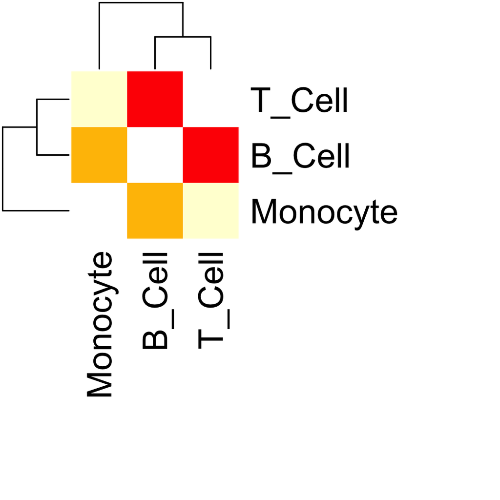

**Figure 1.** Clustering of all the pairwise comparisons. The joint of p value and fold change, *sign(log2FC)*sqrt(abs(log10(p)*logFC))*, is used as a representative statistic of the differential expression of each gene in each comparisons. The representative statistics of all genes are then used for the clustering.

*[Go to project home](http://zhezhangsh.github.io/RoCA)*

## 2.1 Top genes

Selection of the top genes with the most significant meta-analysis results.

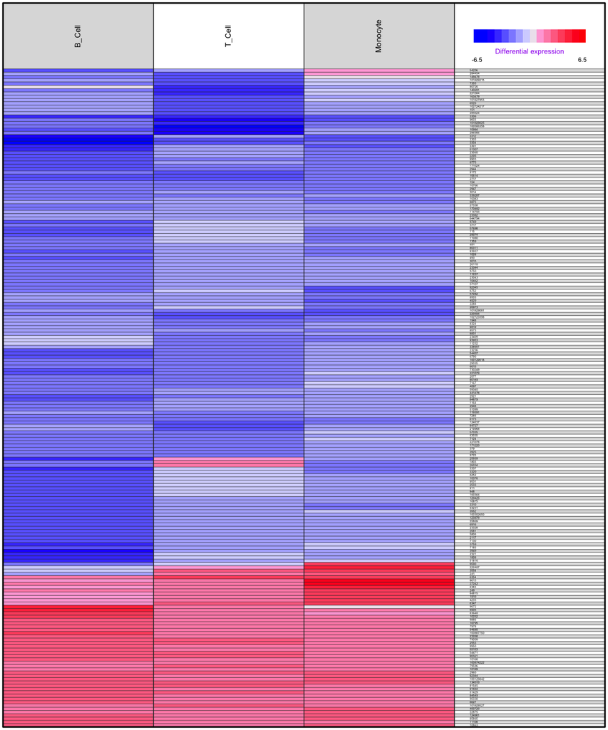

**Figure 2A.** The top genes with the most overall differential expression across all comparisons, based on their representative statistics.

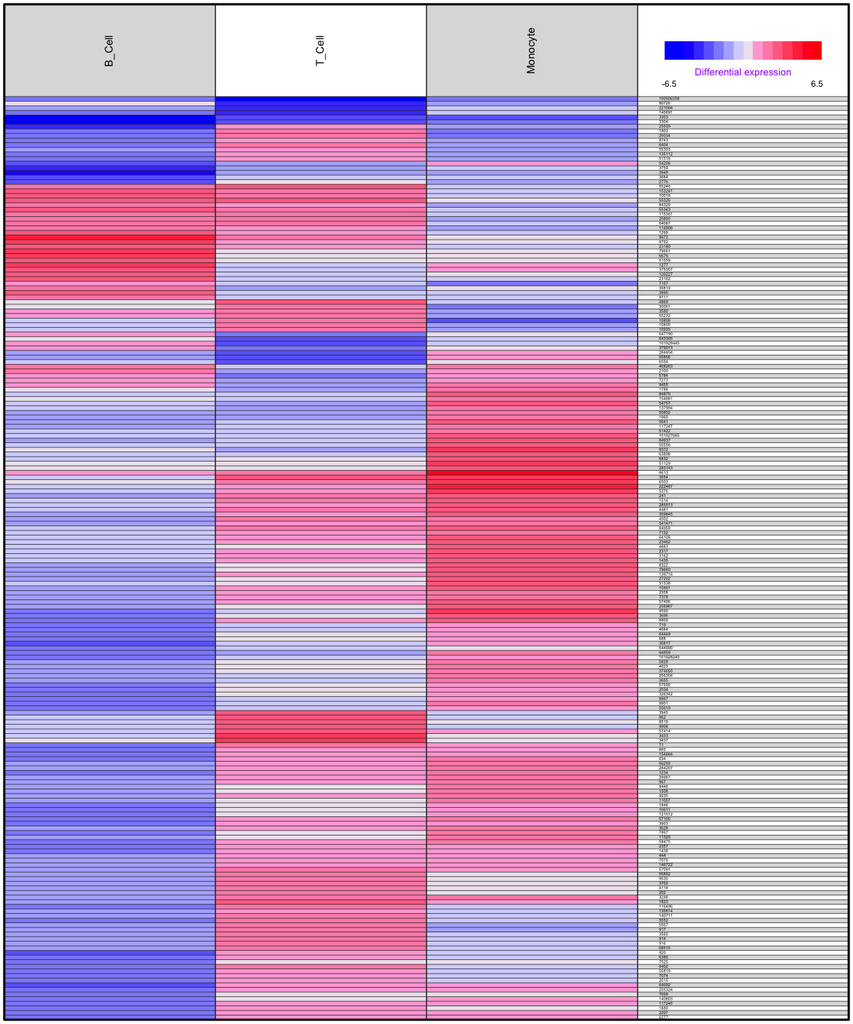

**Figure 2B.** The top genes with the most different results of differential expression between the comparisons, based on their representative statistics.

*[Go to project home](http://zhezhangsh.github.io/RoCA)*

# 3 Gene set-level analysis

Statisitcs of gene set enrichment analysis, p value and normalized enriched score (NES), are retrieved from individual comparisons. Gene sets presented in any of the comparisons are included. [Fisher’s method](https://en.wikipedia.org/wiki/Fisher%27s_method) of meta-analysis is performed on the GSEA p values of individual comparisons to get a combined p value for each gene set. For the meta-analysis, p values of 0 from the original GSEA are rounded to 0.001. Other summary statistics of each gene set include its maximum p value from all comparisons, and the average/minimum of *|NES|* from all comparisons.

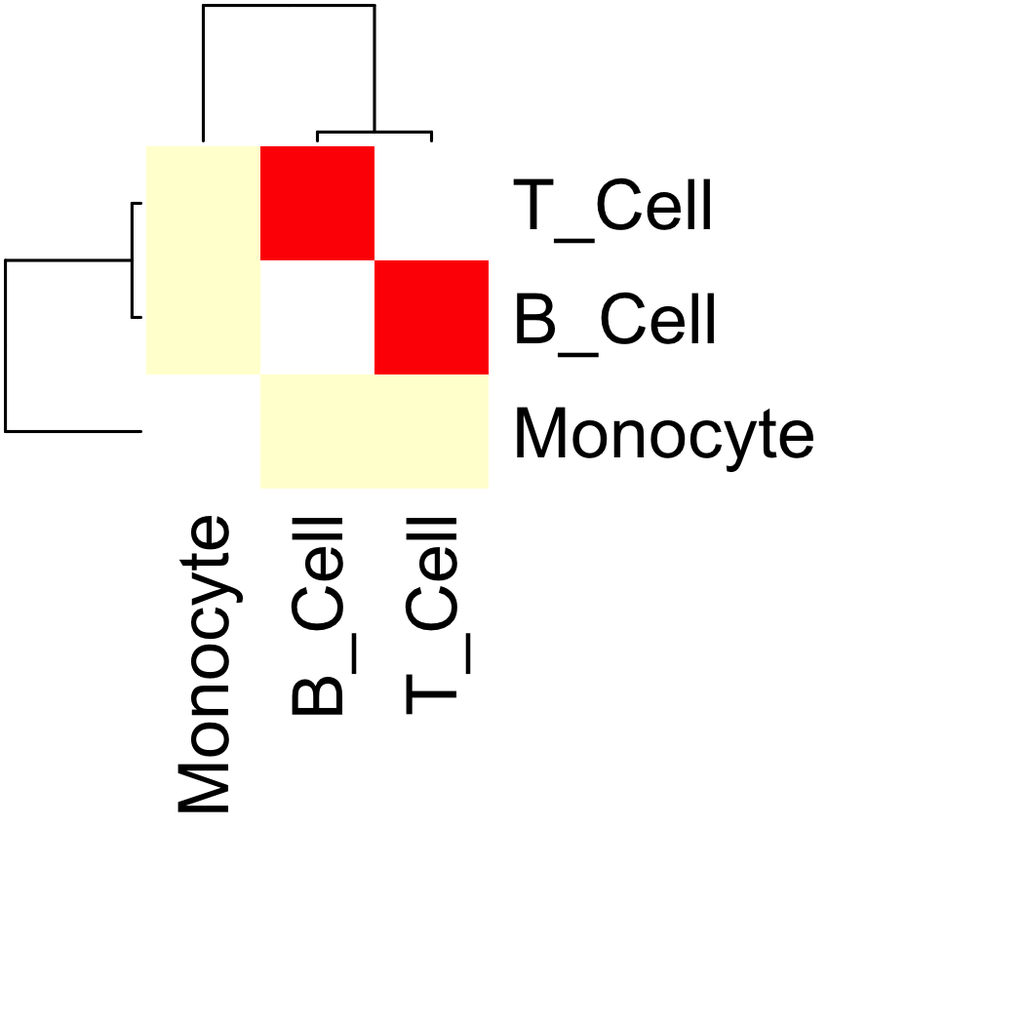

**Figure 3.** Clustering of all the pairwise comparisons, using NES of all gene sets.

*[Go to project home](http://zhezhangsh.github.io/RoCA)*

## 3.1 Top gene sets

Selection of the top gene sets with the most significant meta-analysis results.

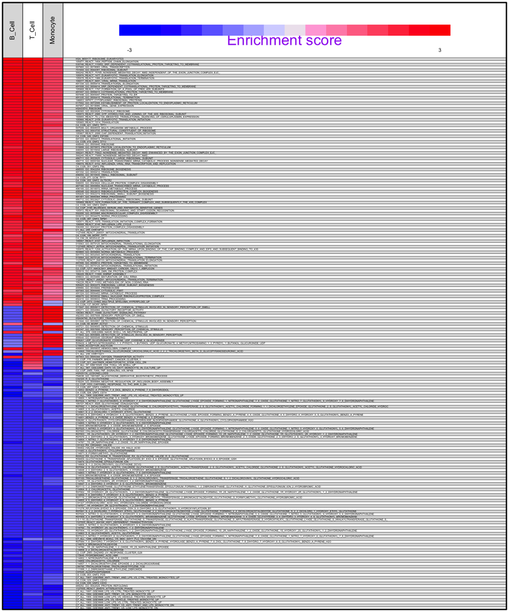

**Figure 4A.** The top gene sets with the highest average *|NES|* of all comparisons.

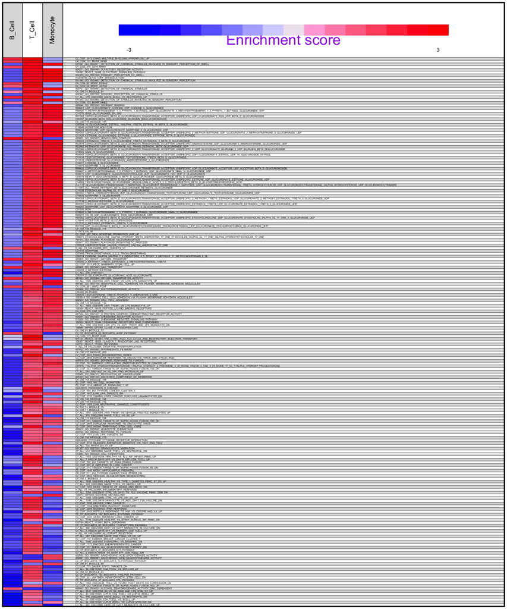

**Figure 4B.** The top gene sets with the most different NES values among all comparisons.

*[Go to project home](http://zhezhangsh.github.io/RoCA)*

## 3.2 Gene set collections

- C0_Hallmark : 50 gene sets
- C1_Positional : 312 gene sets
- C2_BioCarta_Pathways : 217 gene sets
- C2_Chemical_and_genetic_perturbations : 3252 gene sets
- C3_MicroRNA_targets : 213 gene sets
- C3_TF_targets : 573 gene sets
- C4_Cancer_gene_neighborhoods : 427 gene sets
- C4_Cancer_modules : 415 gene sets
- C6_Oncogenic_signatures : 189 gene sets
- C7_Immunologic_signatures : 1910 gene sets
- GO_BP : 7131 gene sets
- GO_CC : 875 gene sets
- GO_MF : 1541 gene sets
- KEGG_compound : 526 gene sets
- KEGG_enzyme : 33 gene sets
- KEGG_module : 128 gene sets
- KEGG_pathway : 285 gene sets
- KEGG_reaction : 193 gene sets
- OMIM_gene : 101 gene sets
- REACTOME : 1372 gene sets
- WikiPathways : 216 gene sets

*[Go to project home](http://zhezhangsh.github.io/RoCA)*

# 4 Appendix

Check out the **[RoCA home page](http://zhezhangsh.github.io/RoCA)** for more information.

## 4.1 Reproduce this report

To reproduce this report:

1. Find the data analysis template you want to use and an example of its pairing YAML file [here](https://github.com/zhezhangsh/RoCA/wiki/Templates-and-examples) and download the YAML example to your working directory
2. To generate a new report using your own input data and parameter, edit the following items in the YAML file:
   - *output* : where you want to put the output files
   - *home* : the URL if you have a home page for your project
   - *analyst* : your name
   - *description* : background information about your project, analysis, etc.
   - *input* : where are your input data, read instruction for preparing them
   - *parameter* : parameters for this analysis; read instruction about how to prepare input data
3. Run the code below within *R Console* or *RStudio*, preferablly with a new R session:

```r
if (!require(devtools)) { install.packages('devtools'); require(devtools); }
if (!require(RCurl)) { install.packages('RCurl'); require(RCurl); }
if (!require(RoCA)) { install_github('zhezhangsh/RoCAR'); require(RoCA); }

CreateReport(filename.yaml);  # filename.yaml is the YAML file you just downloaded and edited for your analysis
```

If there is no complaint, go to the *output* folder and open the *index.html* file to view report.

*[Go to project home](http://zhezhangsh.github.io/RoCA)*

**END OF DOCUMENT**